# project_2_Nandan

## 1. Load the Data

```python
import numpy as np
import pandas as pd
import matplotlib.pyplot as plt
import seaborn as sns

# Load datasets
df_customers = pd.read_csv("Customer_Master_Data.csv")
df_transactions = pd.read_csv("Customer_Transactions.csv")
df_cust = pd.read_excel("Customer_Master_Data.xlsx")
# Preview
print(df_customers.shape)
df_customers.head()
```

```
(1000, 9)
```

|  | CustomerID | Name | Email | Gender | Age | City | MaritalStatus | NumChildren | JoinDate |
| --- | --- | --- | --- | --- | --- | --- | --- | --- | --- |
| 0 | CUST10000 | Onkar Bhargava | pkeer@yahoo.com | Male | 54 | Delhi | Divorced | 0 | 2021-02-22 |
| 1 | CUST10001 | Divit Kohli | mkalita@sarin.com | Female | 48 | Kolkata | Married | 0 | 2023-12-06 |
| 2 | CUST10002 | Kiara Behl | apteanay@hotmail.com | Male | 75 | Kolkata | Widowed | 2 | 2023-08-23 |
| 3 | CUST10003 | Vaibhav Sankar | bseshadri@choudhry.info | Male | 62 | Pune | Divorced | 2 | 2022-11-17 |
| 4 | CUST10004 | Shray D’Alia | bdhillon@toor-mall.com | Male | 55 | Delhi | Divorced | 0 | 2022-12-04 |

```python
df_customers.info()
```

```
<class 'pandas.core.frame.DataFrame'>
RangeIndex: 1000 entries, 0 to 999
Data columns (total 9 columns):
 #   Column         Non-Null Count  Dtype
---  ------         --------------  -----
 0   CustomerID     1000 non-null   object
 1   Name           1000 non-null   object
 2   Email          1000 non-null   object
 3   Gender         1000 non-null   object
 4   Age            1000 non-null   int64
 5   City           1000 non-null   object
 6   MaritalStatus  1000 non-null   object
 7   NumChildren    1000 non-null   int64
 8   JoinDate       1000 non-null   object
dtypes: int64(2), object(7)
memory usage: 70.4+ KB
```

- joinDate should be in datetime
- their is no null data

```python
df_customers.describe()
```

|  | Age | NumChildren |
| --- | --- | --- |
| count | 1000.000000 | 1000.000000 |
| mean | 46.471000 | 1.311000 |
| std | 16.582525 | 1.190671 |
| min | 18.000000 | 0.000000 |
| 25% | 32.000000 | 0.000000 |
| 50% | 46.000000 | 1.000000 |
| 75% | 60.000000 | 2.000000 |
| max | 75.000000 | 4.000000 |

```python
print(df_transactions.shape)
df_transactions.head()
```

```
(23050, 3)
```

|  | CustomerID | TransactionDate | TransactionAmount |
| --- | --- | --- | --- |
| 0 | CUST10771 | 7/31/23 | 2383.07 |
| 1 | CUST10100 | 3/10/24 | 497.54 |
| 2 | CUST10031 | 2/17/25 | 536.78 |
| 3 | CUST10987 | 7/17/23 | 314.89 |
| 4 | CUST10831 | 12/15/24 | 2543.19 |

```python
df_transactions.info()
```

```
<class 'pandas.core.frame.DataFrame'>
RangeIndex: 23050 entries, 0 to 23049
Data columns (total 3 columns):
 #   Column             Non-Null Count  Dtype
---  ------             --------------  -----
 0   CustomerID         23050 non-null  object
 1   TransactionDate    23050 non-null  object
 2   TransactionAmount  23050 non-null  float64
dtypes: float64(1), object(2)
memory usage: 540.4+ KB
```

- TransactionDate should be in datetime
- their is no null data

```python
df_transactions.describe()
```

|  | TransactionAmount |
| --- | --- |
| count | 23050.000000 |
| mean | 1000.138814 |
| std | 703.358978 |
| min | 3.870000 |
| 25% | 482.107500 |
| 50% | 844.755000 |
| 75% | 1346.795000 |
| max | 6890.190000 |

```python
df_cust.head() # xlsx file
```

|  | CustomerID | Name | Email | Gender | Age | City | MaritalStatus | NumChildren | JoinDate |
| --- | --- | --- | --- | --- | --- | --- | --- | --- | --- |
| 0 | CUST10000 | Onkar Bhargava | pkeer@yahoo.com | Male | 54 | Delhi | Divorced | 0 | 2021-02-22 |
| 1 | CUST10001 | Divit Kohli | mkalita@sarin.com | Female | 48 | Kolkata | Married | 0 | 2023-12-06 |
| 2 | CUST10002 | Kiara Behl | apteanay@hotmail.com | Male | 75 | Kolkata | Widowed | 2 | 2023-08-23 |
| 3 | CUST10003 | Vaibhav Sankar | bseshadri@choudhry.info | Male | 62 | Pune | Divorced | 2 | 2022-11-17 |
| 4 | CUST10004 | Shray D’Alia | bdhillon@toor-mall.com | Male | 55 | Delhi | Divorced | 0 | 2022-12-04 |

```python
import warnings
warnings.filterwarnings("ignore")
```

## 2. Clean the Data

## _Convert dates

```python
# Convert dates
df_customers['JoinDate'] = pd.to_datetime(df_customers['JoinDate'])
df_transactions['TransactionDate'] = pd.to_datetime(df_transactions['TransactionDate'])
```

```python
df_customers.info()
```

```
<class 'pandas.core.frame.DataFrame'>
RangeIndex: 1000 entries, 0 to 999
Data columns (total 9 columns):
 #   Column         Non-Null Count  Dtype
---  ------         --------------  -----
 0   CustomerID     1000 non-null   object
 1   Name           1000 non-null   object
 2   Email          1000 non-null   object
 3   Gender         1000 non-null   object
 4   Age            1000 non-null   int64
 5   City           1000 non-null   object
 6   MaritalStatus  1000 non-null   object
 7   NumChildren    1000 non-null   int64
 8   JoinDate       1000 non-null   datetime64[ns]
dtypes: datetime64[ns](1), int64(2), object(6)
memory usage: 70.4+ KB
```

```python
df_transactions.info()
```

```
<class 'pandas.core.frame.DataFrame'>
RangeIndex: 23050 entries, 0 to 23049
Data columns (total 3 columns):
 #   Column             Non-Null Count  Dtype
---  ------             --------------  -----
 0   CustomerID         23050 non-null  object
 1   TransactionDate    23050 non-null  datetime64[ns]
 2   TransactionAmount  23050 non-null  float64
dtypes: datetime64[ns](1), float64(1), object(1)
memory usage: 540.4+ KB
```

- sucessfully convert date from object to datetimes

### _Drop duplicates

```python
df_customers.drop_duplicates(subset="CustomerID", inplace=True)
df_customers.head()
```

|  | CustomerID | Name | Email | Gender | Age | City | MaritalStatus | NumChildren | JoinDate |
| --- | --- | --- | --- | --- | --- | --- | --- | --- | --- |
| 0 | CUST10000 | Onkar Bhargava | pkeer@yahoo.com | Male | 54 | Delhi | Divorced | 0 | 2021-02-22 |
| 1 | CUST10001 | Divit Kohli | mkalita@sarin.com | Female | 48 | Kolkata | Married | 0 | 2023-12-06 |
| 2 | CUST10002 | Kiara Behl | apteanay@hotmail.com | Male | 75 | Kolkata | Widowed | 2 | 2023-08-23 |
| 3 | CUST10003 | Vaibhav Sankar | bseshadri@choudhry.info | Male | 62 | Pune | Divorced | 2 | 2022-11-17 |
| 4 | CUST10004 | Shray D’Alia | bdhillon@toor-mall.com | Male | 55 | Delhi | Divorced | 0 | 2022-12-04 |

### _Ensure all transaction IDs exist in master

```python
valid_ids = df_customers['CustomerID'].unique()
df_transactions = df_transactions[df_transactions['CustomerID'].isin(valid_ids)]
```

### _Check for nulls

```python
print(df_customers.isnull().sum())
print(df_transactions.isnull().sum())
```

```
CustomerID       0
Name             0
Email            0
Gender           0
Age              0
City             0
MaritalStatus    0
NumChildren      0
JoinDate         0
dtype: int64
CustomerID           0
TransactionDate      0
TransactionAmount    0
dtype: int64
```

- their is no null data

## 3.EDA

### _Quick overview

```python
print(df_customers.head())
df_customers.info()
df_customers.describe()
```

```
  CustomerID            Name                    Email  Gender  Age     City  \
0  CUST10000  Onkar Bhargava          pkeer@yahoo.com    Male   54    Delhi
1  CUST10001     Divit Kohli        mkalita@sarin.com  Female   48  Kolkata
2  CUST10002      Kiara Behl     apteanay@hotmail.com    Male   75  Kolkata
3  CUST10003  Vaibhav Sankar  bseshadri@choudhry.info    Male   62     Pune
4  CUST10004    Shray D’Alia   bdhillon@toor-mall.com    Male   55    Delhi

  MaritalStatus  NumChildren   JoinDate
0      Divorced            0 2021-02-22
1       Married            0 2023-12-06
2       Widowed            2 2023-08-23
3      Divorced            2 2022-11-17
4      Divorced            0 2022-12-04
<class 'pandas.core.frame.DataFrame'>
RangeIndex: 1000 entries, 0 to 999
Data columns (total 9 columns):
 #   Column         Non-Null Count  Dtype
---  ------         --------------  -----
 0   CustomerID     1000 non-null   object
 1   Name           1000 non-null   object
 2   Email          1000 non-null   object
 3   Gender         1000 non-null   object
 4   Age            1000 non-null   int64
 5   City           1000 non-null   object
 6   MaritalStatus  1000 non-null   object
 7   NumChildren    1000 non-null   int64
 8   JoinDate       1000 non-null   datetime64[ns]
dtypes: datetime64[ns](1), int64(2), object(6)
memory usage: 70.4+ KB
```

|  | Age | NumChildren | JoinDate |
| --- | --- | --- | --- |
| count | 1000.000000 | 1000.000000 | 1000 |
| mean | 46.471000 | 1.311000 | 2022-07-24 01:36:28.800000256 |
| min | 18.000000 | 0.000000 | 2020-07-29 00:00:00 |
| 25% | 32.000000 | 0.000000 | 2021-07-12 12:00:00 |
| 50% | 46.000000 | 1.000000 | 2022-07-10 12:00:00 |
| 75% | 60.000000 | 2.000000 | 2023-08-05 12:00:00 |
| max | 75.000000 | 4.000000 | 2024-07-28 00:00:00 |
| std | 16.582525 | 1.190671 | NaN |

### Customer Dataset Overview

We begin EDA by inspecting the customer dataset:

- **Size**: 1,000 customers, 9 attributes
- **Data quality**: No missing values, correct data types
- **Key variables**:
  - Age: 18–75 (mean ~46), balanced distribution across quartiles
  - NumChildren: 0–4 (mean ~1.3), majority have 0–2 children
  - JoinDate: July 2020 – July 2024, median July 2022 → steady acquisition trend

**Insights:**

- The customer base is largely middle-aged (30–60 years).
- Family size is small, which may affect purchasing behavior.
- Acquisition has been consistent over 4 years, with half of customers joining after mid-2022.

### _Univariate analysis (single variable)

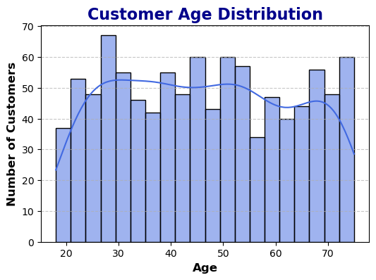

```python
plt.figure(figsize=(6,4))
sns.histplot(df_customers['Age'], bins=20, kde=True, color='royalblue', edgecolor='black')

plt.title("Customer Age Distribution", fontsize=16, fontweight='bold', color='darkblue')
plt.xlabel("Age", fontsize=12, fontweight='bold')
plt.ylabel("Number of Customers", fontsize=12, fontweight='bold')

plt.grid(axis='y', linestyle='--', alpha=0.7)

plt.show()
```

### Age Distribution Analysis

As part of the exploratory data analysis (EDA), we examine the distribution of customer ages.  
The histogram above shows the frequency of customers across different age ranges, with a kernel density estimate (KDE) overlay to highlight the overall trend.

### _Bivariate analysis (two variables)

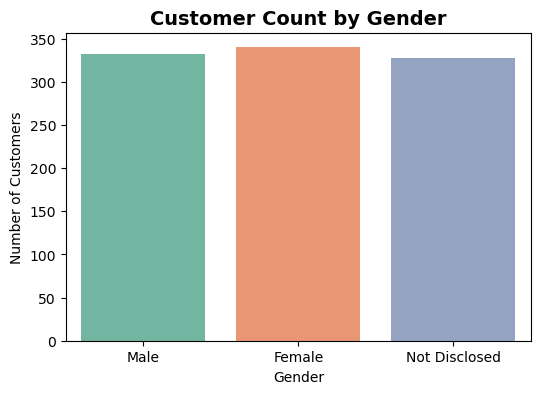

```python
plt.figure(figsize=(6,4))
sns.countplot(x='Gender', data=df_customers, palette='Set2')
plt.title("Customer Count by Gender", fontsize=14, fontweight='bold')
plt.xlabel("Gender")
plt.ylabel("Number of Customers")
plt.show()
```

### Bivariate Analysis: Customer Count by Gender

The countplot above compares the number of customers across gender categories.

**Insights:**

- The distribution is relatively balanced among **Male**, **Female**, and **Not Disclosed** groups, each contributing close to one-third of the customer base.
- This balance suggests that the dataset is diverse and not heavily skewed toward one gender.
- The presence of a significant "Not Disclosed" group highlights that some customers prefer not to reveal gender information, which is important for respecting privacy in segmentation.

**Business Relevance:**

- Balanced gender representation means marketing strategies should remain inclusive rather than overly targeted to one group.
- Campaigns can be designed to appeal broadly, while still offering tailored promotions for specific demographics.
- The "Not Disclosed" segment should be considered in analysis, as these customers may respond better to neutral, non-gendered campaigns.

### _Categorical variable analysis

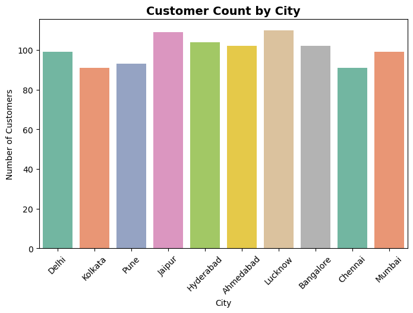

```python
plt.figure(figsize=(8,5))
sns.countplot(x='City', data=df_customers, palette='Set2')
plt.title("Customer Count by City", fontsize=14, fontweight='bold')
plt.xlabel("City")
plt.ylabel("Number of Customers")
plt.xticks(rotation=45)  # rotate labels for readability
plt.show()
```

### Categorical Variable Analysis: Customer Count by City

The bar chart above shows the distribution of customers across major Indian cities.

### _Correlation heatmap (multivariate)

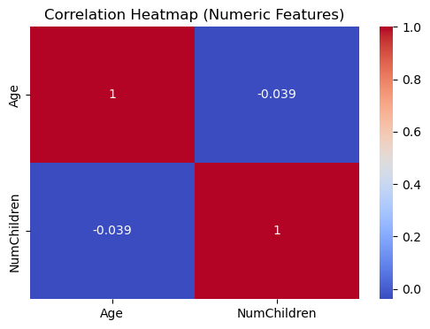

```python
plt.figure(figsize=(6,4))
sns.heatmap(df_customers.select_dtypes(include='number').corr(),
            annot=True, cmap='coolwarm')
plt.title("Correlation Heatmap (Numeric Features)")
plt.show()
```

### Correlation Heatmap (Numeric Features)

The heatmap above shows the correlation between numeric variables in the customer dataset — specifically **Age** and **NumChildren**.

**Insights:**

- Each variable is perfectly correlated with itself (correlation = 1).
- The correlation between **Age** and **NumChildren** is **-0.04**, indicating a very weak negative relationship.
- This suggests that as age increases, the number of children tends to decrease slightly, but the relationship is not strong enough to be statistically meaningful.

**Business Relevance:**

- Since the correlation is weak, age and family size should be treated as largely independent factors in customer segmentation.
- Marketing strategies should consider both attributes separately — for example:
  - Age groups for lifestyle or fashion targeting.
  - Family size for household or family-oriented product promotions.
- Combining these variables in multivariate analysis (e.g., clustering or RFM segmentation) may reveal deeper patterns not captured by simple correlation.

```python
print(df_transactions.head())
df_transactions.info()
df_transactions.describe()
```

```
  CustomerID TransactionDate  TransactionAmount
0  CUST10771      2023-07-31            2383.07
1  CUST10100      2024-03-10             497.54
2  CUST10031      2025-02-17             536.78
3  CUST10987      2023-07-17             314.89
4  CUST10831      2024-12-15            2543.19
<class 'pandas.core.frame.DataFrame'>
RangeIndex: 23050 entries, 0 to 23049
Data columns (total 3 columns):
 #   Column             Non-Null Count  Dtype
---  ------             --------------  -----
 0   CustomerID         23050 non-null  object
 1   TransactionDate    23050 non-null  datetime64[ns]
 2   TransactionAmount  23050 non-null  float64
dtypes: datetime64[ns](1), float64(1), object(1)
memory usage: 540.4+ KB
```

|  | TransactionDate | TransactionAmount |
| --- | --- | --- |
| count | 23050 | 23050.000000 |
| mean | 2024-01-22 02:29:03.618221312 | 1000.138814 |
| min | 2020-08-22 00:00:00 | 3.870000 |
| 25% | 2023-05-07 00:00:00 | 482.107500 |
| 50% | 2024-04-21 00:00:00 | 844.755000 |
| 75% | 2024-12-12 00:00:00 | 1346.795000 |
| max | 2025-07-29 00:00:00 | 6890.190000 |
| std | NaN | 703.358978 |

## Exploratory Data Analysis (EDA) – Transactions Dataset

We begin by examining the structure and summary statistics of the transactions data.

### Dataset Overview

- **Size**: 23,050 transaction records
- **Columns**:
  - `CustomerID` – unique identifier for each customer
  - `TransactionDate` – date of transaction (2020–2025)
  - `TransactionAmount` – monetary value of each transaction
- **Data Quality**: No missing values, correct data types (`object`, `datetime64`, `float64`)

### Business Relevance

- Identifying high-value transactions helps target premium customers for loyalty programs.
- Time-based analysis can reveal seasonal trends and guide promotional campaigns.
- Clean, complete data ensures reliable segmentation and predictive modeling.

### _Transaction amount distribution

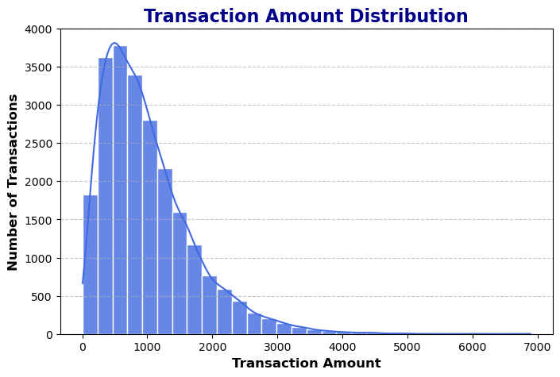

```python
plt.figure(figsize=(8,5))
sns.histplot(df_transactions['TransactionAmount'],
             bins=30, kde=True,
             color='royalblue', edgecolor='white', alpha=0.8)
plt.title("Transaction Amount Distribution", fontsize=16, fontweight='bold', color='darkblue')
plt.xlabel("Transaction Amount", fontsize=12, fontweight='bold')
plt.ylabel("Number of Transactions", fontsize=12, fontweight='bold')
plt.grid(axis='y', linestyle='--', alpha=0.7)
plt.show()
```

### Transaction Amount Distribution

The histogram above shows how transaction amounts are distributed across the dataset.

**Insights:**

- The distribution is **right-skewed**: most transactions are below 1,000, while a few extend up to ~7,000.
- A large cluster of transactions falls between 500–1,300, indicating typical spending behavior.
- High-value outliers exist, but they are rare compared to the bulk of transactions.

**Business Relevance:**

- Most customers make modest purchases, so promotions should target this spending range.
- High-value transactions, though rare, represent premium customers who may benefit from loyalty programs or personalized offers.
- Understanding this distribution helps in designing pricing strategies, detecting anomalies, and segmenting customers by spending behavior.

### _Transactions over time

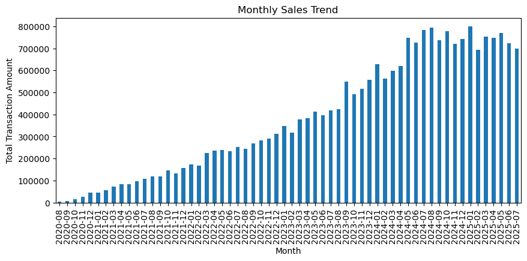

```python
df_transactions['Month'] = df_transactions['TransactionDate'].dt.to_period('M')
monthly_sales = df_transactions.groupby('Month')['TransactionAmount'].sum()
monthly_sales.plot(kind='bar', figsize=(10,4))
plt.title("Monthly Sales Trend")
plt.ylabel("Total Transaction Amount")
plt.show()
```

## Monthly Sales Trend Analysis

The bar chart above shows the total transaction amounts aggregated by month over the period **August 2020 – July 2025**.

### Insights

- **Overall Growth**: There is a clear upward trend in monthly sales, reflecting consistent business growth over the 5-year period.
- **Seasonality**: Fluctuations are visible around 2024–2025, suggesting possible seasonal effects or promotional campaigns driving spikes in sales.
- **Stability**: From 2020 through 2023, growth appears steady and gradual, indicating a stable customer base and reliable transaction flow.
- **Acceleration**: The higher peaks in later years highlight increased customer engagement and potentially larger transaction values.

### Business Relevance

- **Forecasting**: The upward trend supports positive revenue projections and helps in planning future inventory and staffing.
- **Campaign Planning**: Seasonal spikes can be leveraged to design targeted promotions during high-demand months.
- **Customer Engagement**: Sustained growth suggests successful acquisition and retention strategies, which can be further optimized by focusing on peak months.

### _Outlier detection

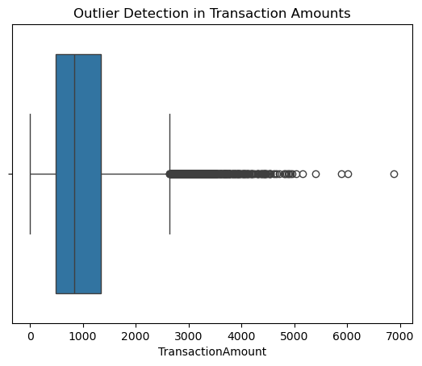

```python
sns.boxplot(x=df_transactions['TransactionAmount'])
plt.title("Outlier Detection in Transaction Amounts")
plt.show()
```

## Outlier Detection – Transaction Amounts

The box plot above highlights the distribution of transaction amounts and identifies potential outliers.

### Business Relevance

- **Premium Customers**: Outliers may represent high-value customers who contribute disproportionately to revenue. They are prime candidates for loyalty programs or personalized offers.
- **Risk Monitoring**: Very large transactions could also signal anomalies or potential fraud, requiring closer monitoring.
- **Segmentation Strategy**: Differentiating between typical spenders and outliers helps refine customer segmentation and marketing campaigns.

## 4. Merge Data

```python
df = pd.merge(df_transactions, df_customers, on="CustomerID", how="left")
print(df.shape)
df.head()
```

```
(23050, 12)
```

|  | CustomerID | TransactionDate | TransactionAmount | Month | Name | Email | Gender | Age | City | MaritalStatus | NumChildren | JoinDate |
| --- | --- | --- | --- | --- | --- | --- | --- | --- | --- | --- | --- | --- |
| 0 | CUST10771 | 2023-07-31 | 2383.07 | 2023-07 | Lakshay Dhillon | dharmajantara@gmail.com | Female | 27 | Ahmedabad | Widowed | 3 | 2023-05-31 |
| 1 | CUST10100 | 2024-03-10 | 497.54 | 2024-03 | Aniruddh Borah | jivikabhavsar@gmail.com | Female | 53 | Lucknow | Divorced | 4 | 2022-01-08 |
| 2 | CUST10031 | 2025-02-17 | 536.78 | 2025-02 | Ritvik Ahuja | jhaverifarhan@chandra.org | Male | 40 | Ahmedabad | Single | 0 | 2023-12-03 |
| 3 | CUST10987 | 2023-07-17 | 314.89 | 2023-07 | Jayan Wagle | ojas82@gmail.com | Not Disclosed | 75 | Bangalore | Widowed | 4 | 2022-03-18 |
| 4 | CUST10831 | 2024-12-15 | 2543.19 | 2024-12 | Ishita Agarwal | vbalay@yahoo.com | Not Disclosed | 27 | Jaipur | Divorced | 4 | 2021-06-30 |

## 5. Perform RFM Calculation

```python
# Reference date = max transaction date + 1
ref_date = df_transactions['TransactionDate'].max() + pd.Timedelta(days=1)

df_rfm = df_transactions.groupby('CustomerID').agg(
    Recency=('TransactionDate', lambda x: (ref_date - x.max()).days),
    Frequency=('TransactionDate', 'count'),
    Monetary=('TransactionAmount', 'sum')
)

df_rfm.head()
```

| CustomerID | Recency | Frequency | Monetary |
| --- | --- | --- | --- |
| CUST10000 | 13 | 23 | 21265.49 |
| CUST10001 | 35 | 30 | 28654.31 |
| CUST10002 | 18 | 24 | 23884.03 |
| CUST10003 | 81 | 25 | 24206.03 |
| CUST10004 | 8 | 19 | 25565.30 |

```python
df_rfm.tail()
```

| CustomerID | Recency | Frequency | Monetary |
| --- | --- | --- | --- |
| CUST10995 | 402 | 21 | 24325.19 |
| CUST10996 | 15 | 21 | 21809.11 |
| CUST10997 | 32 | 20 | 21120.48 |
| CUST10998 | 126 | 25 | 29494.56 |
| CUST10999 | 5 | 23 | 22028.01 |

## 6. Score RFM

```python
# Quantile-based scoring
df_rfm['R_Score'] = pd.qcut(df_rfm['Recency'], 5, labels=[5,4,3,2,1]).astype(int)
df_rfm['F_Score'] = pd.qcut(df_rfm['Frequency'], 5, labels=[1,2,3,4,5]).astype(int)
df_rfm['M_Score'] = pd.qcut(df_rfm['Monetary'], 5, labels=[1,2,3,4,5]).astype(int)

# Combined RFM
df_rfm['RFM_Segment'] = df_rfm['R_Score'].astype(str) + df_rfm['F_Score'].astype(str) + df_rfm['M_Score'].astype(str)
df_rfm['RFM_Score'] = df_rfm[['R_Score','F_Score','M_Score']].sum(axis=1)
df_rfm.head(5)
```

| CustomerID | Recency | Frequency | Monetary | R_Score | F_Score | M_Score | RFM_Segment | RFM_Score |
| --- | --- | --- | --- | --- | --- | --- | --- | --- |
| CUST10000 | 13 | 23 | 21265.49 | 4 | 3 | 2 | 432 | 9 |
| CUST10001 | 35 | 30 | 28654.31 | 3 | 5 | 5 | 355 | 13 |
| CUST10002 | 18 | 24 | 23884.03 | 4 | 3 | 3 | 433 | 10 |
| CUST10003 | 81 | 25 | 24206.03 | 1 | 4 | 3 | 143 | 8 |
| CUST10004 | 8 | 19 | 25565.30 | 5 | 1 | 4 | 514 | 10 |

```python
df_rfm.tail(5)
```

| CustomerID | Recency | Frequency | Monetary | R_Score | F_Score | M_Score | RFM_Segment | RFM_Score |
| --- | --- | --- | --- | --- | --- | --- | --- | --- |
| CUST10995 | 402 | 21 | 24325.19 | 1 | 2 | 3 | 123 | 6 |
| CUST10996 | 15 | 21 | 21809.11 | 4 | 2 | 3 | 423 | 9 |
| CUST10997 | 32 | 20 | 21120.48 | 3 | 2 | 2 | 322 | 7 |
| CUST10998 | 126 | 25 | 29494.56 | 1 | 4 | 5 | 145 | 10 |
| CUST10999 | 5 | 23 | 22028.01 | 5 | 3 | 3 | 533 | 11 |

```python
print(df_rfm.columns)
```

```
Index(['Recency', 'Frequency', 'Monetary', 'R_Score', 'F_Score', 'M_Score',
       'RFM_Segment', 'RFM_Score'],
      dtype='object')
```

## 6. Assign Segment Labels

```python
def segment(row):
    if row['RFM_Segment'] == '555':
        return 'Champion'
    elif row['R_Score'] >= 4 and row['F_Score'] >= 4:
        return 'Loyal Customer'
    elif row['R_Score'] >= 4 and row['F_Score'] <= 3:
        return 'Potential Loyalist'
    elif row['R_Score'] <= 2 and row['F_Score'] >= 3:
        return 'At Risk'
    elif row['R_Score'] == 1 and row['F_Score'] <= 2:
        return 'Lost'
    elif row['M_Score'] >= 4:
        return 'Big Spender'
    else:
        return 'Others'

df_rfm['Segment'] = df_rfm.apply(segment, axis=1)
df_rfm.head()
```

| CustomerID | Recency | Frequency | Monetary | R_Score | F_Score | M_Score | RFM_Segment | RFM_Score | Segment |
| --- | --- | --- | --- | --- | --- | --- | --- | --- | --- |
| CUST10000 | 13 | 23 | 21265.49 | 4 | 3 | 2 | 432 | 9 | Potential Loyalist |
| CUST10001 | 35 | 30 | 28654.31 | 3 | 5 | 5 | 355 | 13 | Big Spender |
| CUST10002 | 18 | 24 | 23884.03 | 4 | 3 | 3 | 433 | 10 | Potential Loyalist |
| CUST10003 | 81 | 25 | 24206.03 | 1 | 4 | 3 | 143 | 8 | At Risk |
| CUST10004 | 8 | 19 | 25565.30 | 5 | 1 | 4 | 514 | 10 | Potential Loyalist |

```python
df_rfm.tail()
```

| CustomerID | Recency | Frequency | Monetary | R_Score | F_Score | M_Score | RFM_Segment | RFM_Score | Segment |
| --- | --- | --- | --- | --- | --- | --- | --- | --- | --- |
| CUST10995 | 402 | 21 | 24325.19 | 1 | 2 | 3 | 123 | 6 | Lost |
| CUST10996 | 15 | 21 | 21809.11 | 4 | 2 | 3 | 423 | 9 | Potential Loyalist |
| CUST10997 | 32 | 20 | 21120.48 | 3 | 2 | 2 | 322 | 7 | Others |
| CUST10998 | 126 | 25 | 29494.56 | 1 | 4 | 5 | 145 | 10 | At Risk |
| CUST10999 | 5 | 23 | 22028.01 | 5 | 3 | 3 | 533 | 11 | Potential Loyalist |

## 7. Visualize Insights

```python
df_rfm.Segment.value_counts()
```

```
Segment
Potential Loyalist    252
At Risk               207
Others                181
Loyal Customer        122
Lost                  105
Big Spender            98
Champion               35
Name: count, dtype: int64
```

### _Count of customers per segment

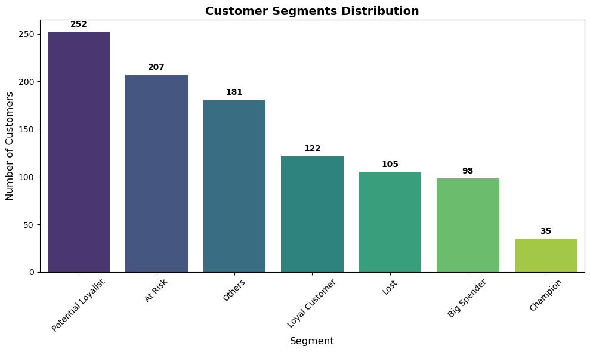

```python
segment_counts = df_rfm['Segment'].value_counts().sort_values(ascending=False)

plt.figure(figsize=(10,6))
sns.barplot(x=segment_counts.index, y=segment_counts.values, palette="viridis")

# Add labels on top of bars
for i, val in enumerate(segment_counts.values):
    plt.text(i, val + 5, str(val), ha='center', fontsize=10, fontweight='bold')

plt.title("Customer Segments Distribution", fontsize=14, fontweight='bold')
plt.xlabel("Segment", fontsize=12)
plt.ylabel("Number of Customers", fontsize=12)
plt.xticks(rotation=45)
plt.tight_layout()
plt.show()
```

### Customer Segments Distribution Analysis

The bar chart illustrates the distribution of customers across different RFM-based segments. Key observations:

**Insight:**  
The distribution shows that while the business has a strong base of *Potential Loyalists*, the high count of *At Risk* customers signals a need for proactive engagement strategies. Focusing on converting *Potential Loyalists* into *Loyal Customers* and retaining *Champions* will maximize long-term revenue and customer lifetime value.

### Customer Segmentation Distribution (Donut Chart Analysis)

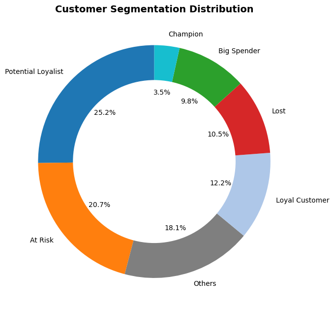

```python
# Data
segments = [
    'Potential Loyalist', 'At Risk', 'Others',
    'Loyal Customer', 'Lost', 'Big Spender', 'Champion'
]
counts = [252, 207, 181, 122, 105, 98, 35]

# Colors for each segment
colors = [
    '#1f77b4', '#ff7f0e', '#7f7f7f',
    '#aec7e8', '#d62728', '#2ca02c', '#17becf'
]

# Create pie chart
fig, ax = plt.subplots(figsize=(7, 7))
wedges, texts, autotexts = ax.pie(
    counts,
    labels=segments,
    autopct='%.1f%%',
    startangle=90,
    colors=colors,
    textprops={'color': 'black', 'fontsize': 10}
)

# Add a white circle at the center to make it a donut
centre_circle = plt.Circle((0, 0), 0.70, fc='white')
fig.gca().add_artist(centre_circle)

# Title and layout
plt.title('Customer Segmentation Distribution', fontsize=14, fontweight='bold')
plt.tight_layout()
plt.show()
```

### Customer Segmentation Distribution (Donut Chart Analysis)

The donut chart provides a percentage breakdown of customers across RFM-based segments. Key insights:

**Strategic Takeaway:**  
The distribution highlights two critical priorities:

1. **Retention** — Address the large *At Risk* segment to reduce churn.
2. **Growth** — Convert *Potential Loyalists* into *Loyal Customers* to strengthen the core base.

### _Revenue contribution per segment

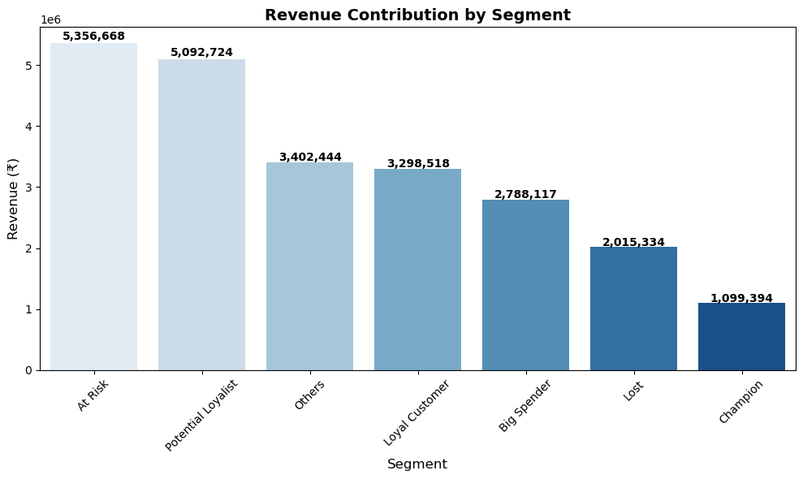

```python
segment_revenue = df_rfm.groupby('Segment')['Monetary'].sum().sort_values(ascending=False)

plt.figure(figsize=(10,6))
sns.barplot(x=segment_revenue.index, y=segment_revenue.values, palette="Blues")

# Add labels on top of bars
for i, val in enumerate(segment_revenue.values):
    plt.text(i, val + (val*0.01), f"{val:,.0f}", ha='center', fontsize=10, fontweight='bold')

plt.title("Revenue Contribution by Segment", fontsize=14, fontweight='bold')
plt.xlabel("Segment", fontsize=12)
plt.ylabel("Revenue (₹)", fontsize=12)
plt.xticks(rotation=45)
plt.tight_layout()
plt.show()
```

### Revenue Contribution by Segment Analysis

The bar chart highlights how different customer segments contribute to overall revenue. Key findings:

**Strategic Takeaway:**  
The analysis shows that the business is heavily dependent on *At Risk* and *Potential Loyalist* segments for revenue. Immediate focus should be on **retaining At Risk customers** and **converting Potential Loyalists into Loyal Customers**. Meanwhile, nurturing *Champions* and *Big Spenders* ensures sustained profitability and brand advocacy.

### _Recency vs Monetary by Segment

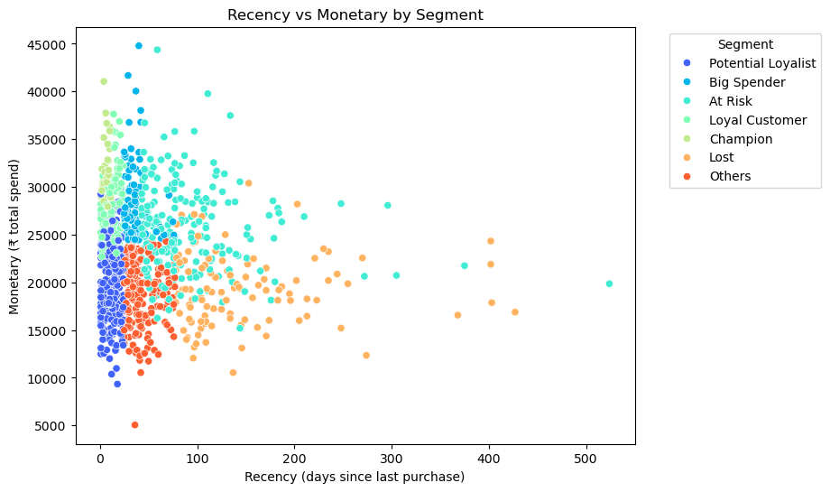

```python
# Scatter plot: Recency vs Monetary by Segment
plt.figure(figsize=(8,6))
sns.scatterplot(data=df_rfm, x='Recency', y='Monetary', hue='Segment', palette='rainbow')
plt.title("Recency vs Monetary by Segment")
plt.xlabel("Recency (days since last purchase)")
plt.ylabel("Monetary (₹ total spend)")
plt.legend(title="Segment", bbox_to_anchor=(1.05, 1), loc='upper left')
plt.show()
```

### Recency vs Monetary Analysis

**Strategic Takeaway:**  
Customers with **high spend but high recency (At Risk)** are the most urgent to target, while **Potential Loyalists** represent the biggest growth opportunity.

### _(Top 20% customers)

```python
# Pareto Analysis (Top 20% customers)
df_rfm_sorted = df_rfm.sort_values('Monetary', ascending=False)
top_20pct = int(0.2 * len(df_rfm_sorted))
pareto_share = df_rfm_sorted.head(top_20pct)['Monetary'].sum() / df_rfm_sorted['Monetary'].sum()
print(f"Top 20% customers contribute {pareto_share:.2%} of revenue")
```

```
Top 20% customers contribute 27.03% of revenue
```

## 8. Dashboard-Style KPI Cards

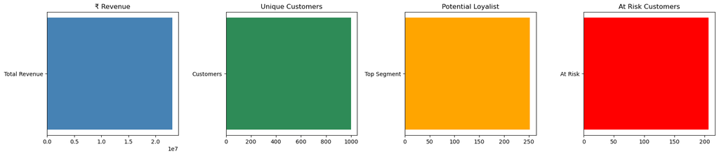

```python
import matplotlib.pyplot as plt

# KPI metrics
total_revenue = df_rfm['Monetary'].sum()
total_customers = df_rfm.shape[0]
top_segment = df_rfm['Segment'].value_counts().idxmax()
at_risk_customers = df_rfm[df_rfm['Segment']=="At Risk"].shape[0]

# Display KPI cards
fig, axes = plt.subplots(1, 4, figsize=(18,4))

# Card 1: Total Revenue
axes[0].barh(["Total Revenue"], [total_revenue], color="steelblue")
axes[0].set_title("₹ Revenue")

# Card 2: Total Customers
axes[1].barh(["Customers"], [total_customers], color="seagreen")
axes[1].set_title("Unique Customers")

# Card 3: Top Segment
axes[2].barh(["Top Segment"], [df_rfm['Segment'].value_counts().max()], color="orange")
axes[2].set_title(top_segment)

# Card 4: At Risk Customers
axes[3].barh(["At Risk"], [at_risk_customers], color="red")
axes[3].set_title("At Risk Customers")

plt.tight_layout()
plt.show()
```

### KPI Dashboard

The four KPI charts summarize the business performance and customer segmentation highlights:

- **₹ Revenue (~20M)**  
  The company has generated strong overall revenue, reflecting healthy sales activity. This serves as the primary indicator of business scale and financial performance.
- **Unique Customers (~1,000)**  
  The customer base is sizable, providing a solid foundation for segmentation and targeted marketing. Maintaining engagement across this base is critical for sustained growth.
- **Potential Loyalists (~250 customers)**  
  This is the largest segment, representing customers with promising buying behavior. They are close to becoming Loyal Customers and should be nurtured with personalized offers and engagement strategies.
- **At Risk Customers (~200 customers)**  
  A significant portion of the customer base is at risk of churn. These customers contribute high revenue but show declining engagement, making retention campaigns essential to protect future earnings.

**Strategic Takeaway:**  
The KPIs highlight a balanced picture: strong revenue and a healthy customer base, but with clear opportunities and risks. The business should focus on **converting Potential Loyalists into Loyal Customers** to strengthen retention, while simultaneously **re‑engaging At Risk customers** to prevent revenue leakage. Together, these actions will maximize customer lifetime value and ensure sustainable growth.

### 9.RFM visualizations

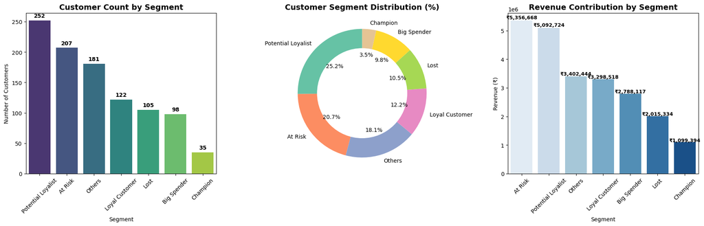

```python
# 1. Count of customers per segment
segment_counts = df_rfm['Segment'].value_counts().sort_values(ascending=False)

# 2. Percentage share (for donut chart)
segment_percent = segment_counts / segment_counts.sum() * 100

# 3. Revenue contribution per segment
segment_revenue = df_rfm.groupby('Segment')['Monetary'].sum().sort_values(ascending=False)

# -----------------------------
# Visualization Dashboard
# -----------------------------
fig, axes = plt.subplots(1, 3, figsize=(18,6))

# Bar chart: customer counts
sns.barplot(x=segment_counts.index, y=segment_counts.values, palette="viridis", ax=axes[0])
axes[0].set_title("Customer Count by Segment", fontsize=14, fontweight='bold')
axes[0].set_ylabel("Number of Customers")
axes[0].set_xlabel("Segment")
axes[0].tick_params(axis='x', rotation=45)
for i, val in enumerate(segment_counts.values):
    axes[0].text(i, val+5, str(val), ha='center', fontsize=10, fontweight='bold')

# Donut chart: percentage share
wedges, texts, autotexts = axes[1].pie(segment_percent, labels=segment_percent.index,
                                       autopct='%1.1f%%', startangle=90, colors=sns.color_palette("Set2"))
centre_circle = plt.Circle((0,0),0.70,fc='white')
axes[1].add_artist(centre_circle)
axes[1].set_title("Customer Segment Distribution (%)", fontsize=14, fontweight='bold')

# Bar chart: revenue contribution
sns.barplot(x=segment_revenue.index, y=segment_revenue.values, palette="Blues", ax=axes[2])
axes[2].set_title("Revenue Contribution by Segment", fontsize=14, fontweight='bold')
axes[2].set_ylabel("Revenue (₹)")
axes[2].set_xlabel("Segment")
axes[2].tick_params(axis='x', rotation=45)
for i, val in enumerate(segment_revenue.values):
    axes[2].text(i, val + (val*0.01), f"₹{val:,.0f}", ha='center', fontsize=9, fontweight='bold')

plt.tight_layout()
plt.show()
```